- Overview
- Resources
- Packages
  - statistical packages
  - base packages
  - Settings
- Chapter 1 - Overview
  - Simple Example with `stan_glm`
- Chapter 3 - Basic Methods
  - Log-Log Interpretation
    - Example Model
    - Interpretation
      - Interpretation from `Regression and Other Stores`
      - Interpretation from `Introductory Econometrics 7e`
    - Predictions
    - Simulation of Log-Log Predictions
- Chapter 4 - Statistcal Inference
  - Confidence Interval of Proportion
- Chapter 5 - Simulation
  - How many girls in 400 births?
  - Simulation of continuous and mixed discrete/continuous models
  - Median Absolute Deviation (`MAD SD`)
- Chapter 9 - Prediction and Bayesian Inference
- pg. 104 describes how sigma (residual standard deviation) is calculated.
  - Point Prediction
  - Linear Predictor with Uncertainty
  - Predictive Distribution
  - 9.3 Prior Information and Bayesian Synthesis
  - 9.5 Uniform, weakly informative, and informative priors in regression
    - Uniform prior distribution
    - Default Prior Distribution
    - Weekly informative prior distribution based on subject-matter knowledge
- Chapter 10
  - Example: uncertainty in predicting congressional elections
  - Fitting the same model to many datasets
- Chapter 11
  - Comparing data to replications from a fitted model
  - 11.6 Residual Standard Deviation and Explained R^2
    - `loo()` & `Posterior Predictive Log Score`
    - `loo_compare`
    - loo `R^2` and other metrics
  - 11.8 Cross Validation
- Chapter 12 - Transformations and regression

# Overview

This document includes examples and exercises from `Regression and Other Stories` by Andrew Gelman, Jennifer Hill and Aki Vehtari, 2020, first edition.

# Resources

[Errata](https://avehtari.github.io/ROS-Examples/errata.html)

[Authors’ Code](https://avehtari.github.io/ROS-Examples/examples.html#Examples_by_chapters)

# Packages

## statistical packages

```r
library(rstan)
library(rstanarm)
library(bayesplot)
library(loo)
```

## base packages

```r
library(broom)
library(broom.mixed)

library(tidyverse)
library(ggplot2)
library(scales)
library(ggridges)
```

## Settings

```r
theme_set(theme_light())
options(scipen=999) # non-scientific notation
options(dplyr.summarise.inform=F)
```

# Chapter 1 - Overview

## Simple Example with `stan_glm`

Load in the data:

```r
head(hibbs)
```

```
##   year growth  vote inc_party_candidate other_candidate
## 1 1952   2.40 44.60           Stevenson      Eisenhower
## 2 1956   2.89 57.76          Eisenhower       Stevenson
## 3 1960   0.85 49.91               Nixon         Kennedy
## 4 1964   4.21 61.34             Johnson       Goldwater
## 5 1968   3.02 49.60            Humphrey           Nixon
## 6 1972   3.62 61.79               Nixon        McGovern
```

Graph data:

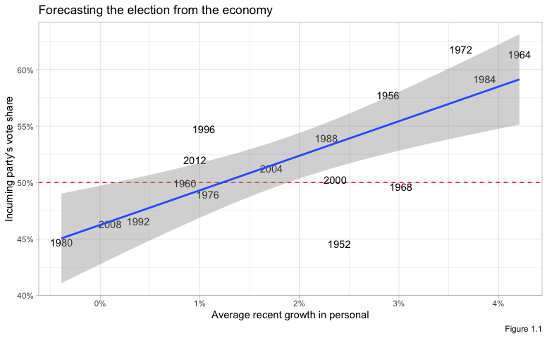

```r
hibbs %>%
    ggplot(aes(x=growth, y=vote)) +
    geom_hline(yintercept = 50, color="red", linetype="dashed") +
    geom_text(aes(label=year)) +
    geom_smooth(method='lm') +
    scale_x_continuous(labels=function(.x)paste0(.x, '%')) +
    scale_y_continuous(labels=function(.x)paste0(.x, '%')) +
    labs(title="Forecasting the election from the economy",
         y="Incuming party's vote share",
         x="Average recent growth in personal",
         caption='Figure 1.1')
```

Build Model:

```r
model <- stan_glm(vote ~ growth, data=hibbs)
```

Model Summary:

```r
summary(model)
```

```
##
## Model Info:
##  function:     stan_glm
##  family:       gaussian [identity]
##  formula:      vote ~ growth
##  algorithm:    sampling
##  sample:       4000 (posterior sample size)
##  priors:       see help('prior_summary')
##  observations: 16
##  predictors:   2
##
## Estimates:
##               mean   sd   10%   50%   90%
## (Intercept) 46.3    1.8 44.1  46.3  48.5
## growth       3.0    0.8  2.1   3.0   4.0
## sigma        4.0    0.8  3.1   3.9   5.1
##
## Fit Diagnostics:
##            mean   sd   10%   50%   90%
## mean_PPD 52.0    1.4 50.3  52.0  53.8
##
## The mean_ppd is the sample average posterior predictive distribution of the outcome variable (for details see help('summary.stanreg')).
##
## MCMC diagnostics
##               mcse Rhat n_eff
## (Intercept)   0.0  1.0  3092
## growth        0.0  1.0  3203
## sigma         0.0  1.0  2539
## mean_PPD      0.0  1.0  3815
## log-posterior 0.0  1.0  1464
##
## For each parameter, mcse is Monte Carlo standard error, n_eff is a crude measure of effective sample size, and Rhat is the potential scale reduction factor on split chains (at convergence Rhat=1).
```

Print()

```r
print(model)
```

```
## stan_glm
##  family:       gaussian [identity]
##  formula:      vote ~ growth
##  observations: 16
##  predictors:   2
## ------
##             Median MAD_SD
## (Intercept) 46.3    1.7
## growth       3.0    0.7
##
## Auxiliary parameter(s):
##       Median MAD_SD
## sigma 3.9    0.8
##
## ------
## * For help interpreting the printed output see ?print.stanreg
## * For info on the priors used see ?prior_summary.stanreg
```

Model Coefficients:

```r
coef(model)
```

```
## (Intercept)      growth
##    46.28277     3.04144
```

Compare to `lm()`:

```r
summary(lm(vote ~ growth, data=hibbs))
```

```
##
## Call:
## lm(formula = vote ~ growth, data = hibbs)
##
## Residuals:
##     Min      1Q  Median      3Q     Max
## -8.9929 -0.6674  0.2556  2.3225  5.3094
##
## Coefficients:
##             Estimate Std. Error t value           Pr(>|t|)
## (Intercept)  46.2476     1.6219  28.514 0.0000000000000841 ***
## growth        3.0605     0.6963   4.396            0.00061 ***
## ---
## Signif. codes:  0 '***' 0.001 '**' 0.01 '*' 0.05 '.' 0.1 ' ' 1
##
## Residual standard error: 3.763 on 14 degrees of freedom
## Multiple R-squared:  0.5798, Adjusted R-squared:  0.5498
## F-statistic: 19.32 on 1 and 14 DF,  p-value: 0.00061
```

(pretty close)

Graph using model coefficients rather than `geom_smooth(method='lm')`

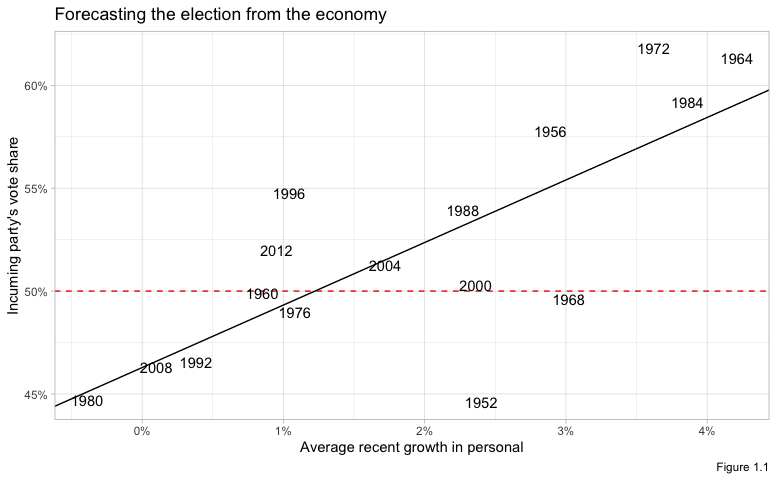

```r
hibbs %>%
    ggplot(aes(x=growth, y=vote)) +
    geom_hline(yintercept = 50, color="red", linetype="dashed") +
    geom_text(aes(label=year)) +
    #geom_smooth(method='lm') +
    geom_abline(intercept = coef(model)['(Intercept)'], slope = coef(model)['growth']) +
    scale_x_continuous(labels=function(.x)paste0(.x, '%')) +
    scale_y_continuous(labels=function(.x)paste0(.x, '%')) +
    labs(title="Forecasting the election from the economy",
         y="Incuming party's vote share",
         x="Average recent growth in personal",
         caption='Figure 1.1')
```

# Chapter 3 - Basic Methods

## Log-Log Interpretation

Example from `Regression & Other Stories pg 39. (Data found elsewhere.)

### Example Model

```r
head(metabolic_rate)
```

```
## # A tibble: 6 x 2
##   `Primate Mass` `Metabolic Rate`
##            <dbl>            <dbl>
## 1           4670            11.6
## 2           1020             2.56
## 3            206             0.73
## 4            190             0.86
## 5            105             0.55
## 6            300             1.1
```

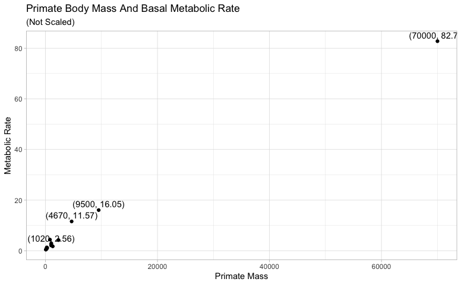

```r
metabolic_rate %>%
    ggplot(aes(x=`Primate Mass`, y=`Metabolic Rate`)) +
    geom_point() +
    geom_text(data=metabolic_rate,
              aes(x=`Primate Mass`, y=`Metabolic Rate`,
                  label=glue::glue("({ `Primate Mass` }, { `Metabolic Rate` })"),
                  color=NULL),
              vjust=-0.5, check_overlap = TRUE) +
    labs(title="Primate Body Mass And Basal Metabolic Rate",
         subtitle = "(Not Scaled)")
```

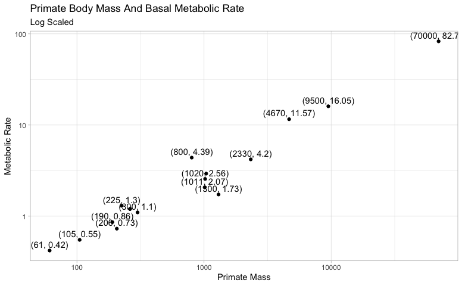

```r
metabolic_rate %>%
    ggplot(aes(x=`Primate Mass`, y=`Metabolic Rate`)) +
    geom_point() +
    geom_text(data=metabolic_rate,
              aes(x=`Primate Mass`, y=`Metabolic Rate`,
                  label=glue::glue("({ `Primate Mass` }, { `Metabolic Rate` })"),
                  color=NULL),
              vjust=-0.5, check_overlap = TRUE) +
    scale_x_log10() +
    scale_y_log10() +
    labs(title="Primate Body Mass And Basal Metabolic Rate",
         subtitle = "Log Scaled")
```

```r
model <- lm(log(`Metabolic Rate`) ~ log(`Primate Mass`), data=metabolic_rate)
summary(model)
```

```
##
## Call:
## lm(formula = log(`Metabolic Rate`) ~ log(`Primate Mass`), data = metabolic_rate)
##
## Residuals:
##      Min       1Q   Median       3Q      Max
## -0.71136 -0.13959  0.01586  0.14175  0.57990
##
## Coefficients:
##                     Estimate Std. Error t value        Pr(>|t|)
## (Intercept)         -4.05787    0.28770  -14.11 0.0000000004613 ***
## log(`Primate Mass`)  0.74160    0.04198   17.66 0.0000000000189 ***
## ---
## Signif. codes:  0 '***' 0.001 '**' 0.01 '*' 0.05 '.' 0.1 ' ' 1
##
## Residual standard error: 0.2983 on 15 degrees of freedom
## Multiple R-squared:  0.9541, Adjusted R-squared:  0.9511
## F-statistic:   312 on 1 and 15 DF,  p-value: 0.00000000001891
```

```r
coef(model)
```

```
##         (Intercept) log(`Primate Mass`)
##           -4.057868            0.741598
```

### Interpretation

#### Interpretation from `Regression and Other Stores`

From `pg. 40`

“For example, when increasing body mass on this curve by a factor of 2, metabolic rate is multiplied by `2^0.74` = `1.7`. Multiplying body mass by `10` corresponds to multiplying metabolic rate by `10^0.74` = `5.5`, and so forth.”

```r
(primate_mass_coefficient <- unname(coef(model)['log(`Primate Mass`)']))
```

```
## [1] 0.741598
```

Lets test this. We’ll start with a body mass of `105`.

```r
(log_prediction_105 <- predict(model, newdata = data.frame(`Primate Mass`=105, check.names = FALSE)))
```

```
##       1
## -0.6065
```

```r
(prediction_105 <- exp(log_prediction_105))
```

```
##         1
## 0.5452559
```

Our prediction of the metabolic rate is `0.5452559`.

What is our prediction if we **double** the body mass?

We would expect a Metabolic Rate of `0.9116825`.

```r
2^primate_mass_coefficient * prediction_105
```

```
##         1
## 0.9116825
```

What is the actual prediction if we double the body mass?

```r
log_prediction_210 <- predict(model, newdata = data.frame(`Primate Mass`=210, check.names = FALSE))
(prediction_210 <- exp(log_prediction_210))
```

```
##         1
## 0.9116825
```

What is our prediction if we multiply body mass by `10`?

We would expect a Metabolic Rate of `3.0074496`.

```r
10^primate_mass_coefficient * prediction_105
```

```
##       1
## 3.00745
```

```r
log_prediction_1050 <- predict(model, newdata = data.frame(`Primate Mass`=1050, check.names = FALSE))
(prediction_1050 <- exp(log_prediction_1050))
```

```
##       1
## 3.00745
```

#### Interpretation from `Introductory Econometrics 7e`

> "A one-unit difference in `log x` corresponds to an additive difference of `b` in `log y`. (R&OS pg. 39)

This is essentially “elasticity” and is interpreted as a `1%` change in x has a `b`% change in `y` (Intro Econometrics pg. 39), although this does not hold for large changes in `y` (Intro Econometrics pg. 186).

```r
format_percent <- function(.x) { paste0(round(.x, 3), '%')}
format_percent_scale <- function(.x) { paste0(round(.x * 100, 3), '%')}

(expected_one_percent_change <- format_percent(primate_mass_coefficient))
```

```
## [1] "0.742%"
```

So, the interpretation of the `log(Primate Mass)` coefficient is that a `1%` change in `Primate Mass` results in a `~0.742%` change in `Metabolic Rate`.

Let’s see if this is true.

If the `Primate Mass` is `105` then our prediction of `log(Metabolic Rate`) is `-0.6065`, which means our prediction of `Metabolic Rate` is `0.5452559`, which matches the point on the graph.

Now let’s change `Primate Mass` (x) by `1%` and see how much `Metabolic Rate` (y) changes by.

```r
(one_percent_change <- (0.01 * 105) + 105)
```

```
## [1] 106.05
```

```r
one_percent_change_prediction <- predict(model, newdata = data.frame(`Primate Mass`=one_percent_change, check.names = FALSE))
(one_percent_change_prediction <- exp(one_percent_change_prediction))
```

```
##         1
## 0.5492943
```

So if `Primate Mass` is `106.05` then we predict that `Metabolic Rate` is `0.5492943`.

So a `1%` change in `Primate Mass` resulted in the following percent change for `Metabolic Rate`:

```r
format_percent_scale((one_percent_change_prediction - prediction_105) / prediction_105)
```

```
## [1] "0.741%"
```

Which matches the expected percent change from the coefficient.

```r
primate_mass_coefficient
```

```
## [1] 0.741598
```

Now, lets try with a larger change.

Lets predict `Metabolic Change` for a `Primate Mass` of `9,500`

```r
(percent_change <- (9500 - 105) / 105)
```

```
## [1] 89.47619
```

The percent-change in `Primate Mass` between these two values is `8947.619%`.

```r
(expected_percent_change_y <- as.numeric(coef(model)["log(`Primate Mass`)"]) * percent_change)
```

```
## [1] 66.35536
```

Therefore, if `Primate Mass` changes by `8947.619%`, the **expected** percent change in `Metabolic Rate` should be `6635.536%`.

But the actual percent change is:

```r
(prediction_9500 <- exp(predict(model, newdata = data.frame(`Primate Mass`=9500, check.names = FALSE))))
```

```
##        1
## 15.40147
```

```r
format_percent_scale((prediction_9500 - prediction_105) / prediction_105)
```

```
## [1] "2724.632%"
```

Which is quite lower than what we expected.

So this rule of thumb doesn’t work across large changes in `y`.

### Predictions

According to `Introductory Econometrics, Wooldridge (pg. 206)`,

> Because the exponential undoes the log, our first guess for predicting y (when dependent variable is log(y)) is to simply exponentiate the predicted value for `log(y): y_predicted = exp(log y_predicted))`. **This does not work; in fact, it will systematically underestimate the expected value of y**.

One adjustment that the author describes is the `Duan smearing estimate`.

> Given an esimtate `a0`, we can predict `y` as

> `y_predicted = a0 * exp(log y_predicted)`

where,

> `a0 = sum(exp(residuals)) / N`

The code below implements the `Duan smearing estimate`.

Note, that this adjustment necessary, not just for `log y = log x` models, but for `log y = x` models (any time the dependent variable is log y, regardless of X).

```r
#' This method returns the adjustment coefficient described in `Introductory Econometrics, Wooldridge (pg. 206)`
#' @param .model the regression model
duan_smearing_adjustment <- function(.model) {
    model_residuals <- residuals(.model)
    duan_smearing_coefficient <- sum(exp(model_residuals)) / length(model_residuals)

    return (duan_smearing_coefficient)
}

#' This method returns the prediction of `y`, when the dependent variable is `log y`, based on the adjustment coefficient described in `Introductory Econometrics, Wooldridge (pg. 206)`
#' @param .model the regression model
#' @param .newdata the data (e.g. test data) from which predictions will be generated
predict_from_log_y <- function(.model, .newdata) {

    duan_smearing_coefficient <- duan_smearing_adjustment(.model)
    .predictions <- predict(.model, newdata=.newdata)
    .predictions <- duan_smearing_coefficient*exp(.predictions)

    return (.predictions)
}
```

Now, let’s create predictions for all `Primate Masses` between `50` and `80000`, which is around the interval of our data.

```r
model <- lm(log(`Metabolic Rate`) ~ log(`Primate Mass`), data=metabolic_rate)
all_predictions <- data.frame(`Primate Mass`=seq(50, 80000), check.names = FALSE)
log_y_predictions <- predict(model, newdata=all_predictions)

# this simple adjustment is also described on pg 206 but assumes normal residuals
all_predictions$`Predictions - Unadjusted` <- exp(log_y_predictions)
all_predictions$`Predictions - Adjusted - Simple` <- exp(((summary(model)$sigma)^2)/2)*exp(log_y_predictions)
all_predictions$`Predictions - Adjusted - Duan` <- predict_from_log_y(.model=model, .newdata=all_predictions)
head(all_predictions)
```

```
##   Primate Mass Predictions - Unadjusted Predictions - Adjusted - Simple
## 1           50                0.3145163                       0.3288212
## 2           51                0.3191693                       0.3336858
## 3           52                0.3237987                       0.3385258
## 4           53                0.3284052                       0.3433418
## 5           54                0.3329892                       0.3481343
## 6           55                0.3375514                       0.3529040
##   Predictions - Adjusted - Duan
## 1                     0.3266032
## 2                     0.3314350
## 3                     0.3362423
## 4                     0.3410258
## 5                     0.3457860
## 6                     0.3505236
```

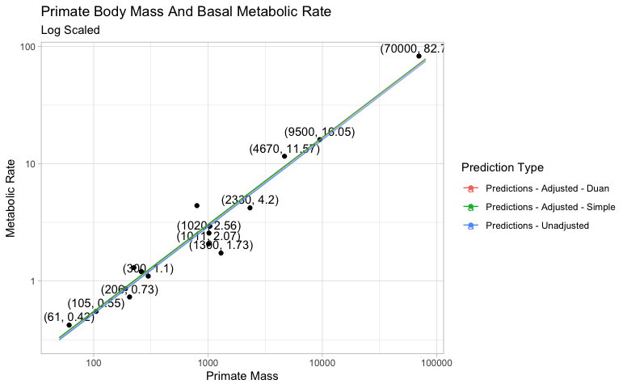

```r
predictions_long <- all_predictions %>%
    # get the original values, where applicable
    #left_join(metabolic_rate, by = 'Primate Mass') %>%
    pivot_longer(-`Primate Mass`, names_to = 'Prediction Type', values_to='Metabolic Rate')

metabolic_rate_plot <- predictions_long %>%
    ggplot(aes(x=`Primate Mass`, y=`Metabolic Rate`, color=`Prediction Type`)) +
    geom_point(data=metabolic_rate, aes(x=`Primate Mass`, y=`Metabolic Rate`, color=NULL)) +
    geom_text(data=metabolic_rate,
              aes(x=`Primate Mass`, y=`Metabolic Rate`,
                  label=glue::glue("({ `Primate Mass` }, { `Metabolic Rate` })"),
                  color=NULL),
              vjust=-0.5, check_overlap = TRUE) +
    geom_line()

metabolic_rate_plot +
    scale_x_log10() +
    scale_y_log10() +
    labs(title="Primate Body Mass And Basal Metabolic Rate",
         subtitle = "Log Scaled")
```

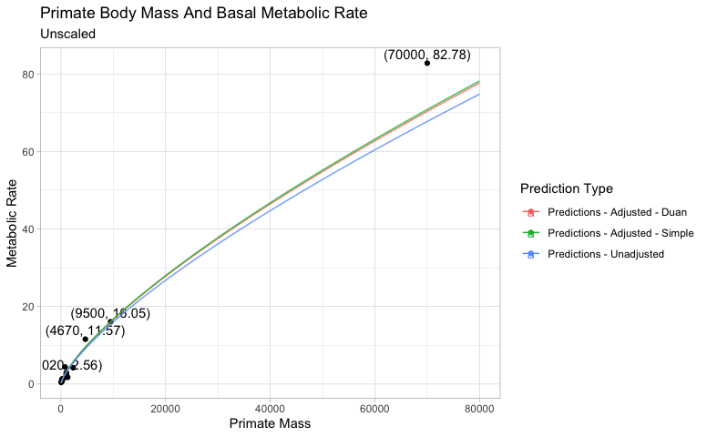

```r
metabolic_rate_plot +
    labs(title="Primate Body Mass And Basal Metabolic Rate",
         subtitle = "Unscaled")
```

### Simulation of Log-Log Predictions

See discussion in previous section regarding systematic underprediction of `y` when dependent varaible is `log y`.

`log y = a + b*log x + random-noise`

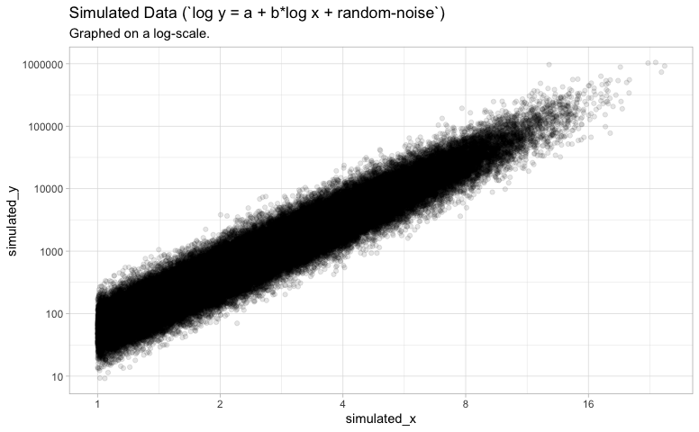

```r
set.seed(1)
intercept <- 4
b_coefficient <- 3
simulated_x <- rexp(100000, rate = 0.5) + 1
noise <- rnorm(100000, sd = 0.5)

simulated_y <- exp(intercept + b_coefficient*log(simulated_x) + noise)

simulated_data <- data.frame(simulated_x, simulated_y)
simulated_data %>%
    ggplot(aes(x=simulated_x, y=simulated_y)) +
    geom_point(alpha=0.1) +
    scale_x_log10(breaks=2^seq(0,6)) +
    scale_y_log10(breaks=10^seq(1,6)) +
    labs(title="Simulated Data (`log y = a + b*log x + random-noise`)",
         subtitle = "Graphed on a log-scale.")
```

Create training/test sets, fit model on training data.

```r
training_indices <- sample.int(n=nrow(simulated_data), size = 0.7*nrow(simulated_data), replace = FALSE)
training_data <- simulated_data[training_indices,]
test_data <- simulated_data[-training_indices,]
model <- lm(log(simulated_y) ~ log(simulated_x), data=training_data)
summary(model)
```

```
##
## Call:
## lm(formula = log(simulated_y) ~ log(simulated_x), data = training_data)
##
## Residuals:
##     Min      1Q  Median      3Q     Max
## -2.1152 -0.3373 -0.0019  0.3348  2.1345
##
## Coefficients:
##                  Estimate Std. Error t value            Pr(>|t|)
## (Intercept)      4.001214   0.003572  1120.1 <0.0000000000000002 ***
## log(simulated_x) 2.999279   0.003273   916.3 <0.0000000000000002 ***
## ---
## Signif. codes:  0 '***' 0.001 '**' 0.01 '*' 0.05 '.' 0.1 ' ' 1
##
## Residual standard error: 0.499 on 69998 degrees of freedom
## Multiple R-squared:  0.923,  Adjusted R-squared:  0.923
## F-statistic: 8.396e+05 on 1 and 69998 DF,  p-value: < 0.00000000000000022
```

Predict on test data.

```r
log_y_predictions <- predict(model, newdata=test_data)

# this simple adjustment is also described on pg 206 but assumes normal residuals
test_data$`Predictions - Unadjusted` <- exp(log_y_predictions)
test_data$`Predictions - Adjusted - Simple` <- exp(((summary(model)$sigma)^2)/2)*exp(log_y_predictions)
test_data$`Predictions - Adjusted - Duan` <- predict_from_log_y(.model=model, .newdata=test_data)
head(test_data)
```

```
##    simulated_x simulated_y Predictions - Unadjusted
## 2     3.363286   3187.9213                2077.8609
## 6     6.789937  25807.5974               17088.4407
## 8     2.079366    495.4461                 491.2115
## 10    1.294092    110.9351                 118.4459
## 12    2.524060    700.3071                 878.4439
## 17    4.752070   3923.7267                5859.5674
##    Predictions - Adjusted - Simple Predictions - Adjusted - Duan
## 2                        2353.3864                     2354.6418
## 6                       19354.3771                    19364.7015
## 8                         556.3464                      556.6431
## 10                        134.1518                      134.2234
## 12                        994.9260                      995.4568
## 17                       6636.5492                     6640.0894
```

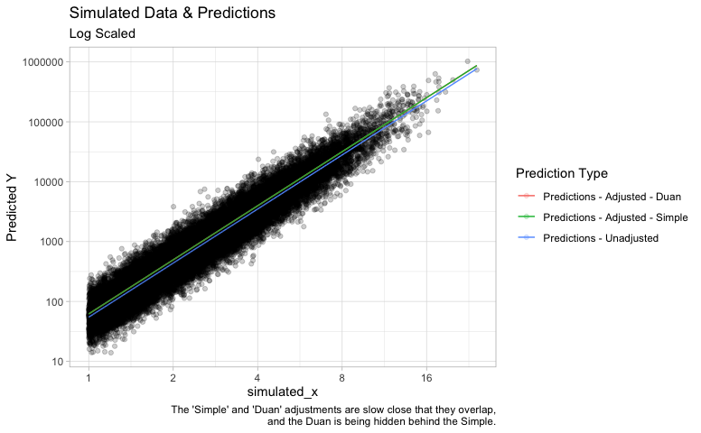

```r
predictions_long <- test_data %>%
    select(-simulated_y) %>%
    # get the original values, where applicable
    #left_join(metabolic_rate, by = 'Primate Mass') %>%
    pivot_longer(-simulated_x, names_to = 'Prediction Type', values_to='Predicted Y')

simulated_plot <- predictions_long %>%
    ggplot(aes(x=simulated_x, y=`Predicted Y`, color=`Prediction Type`)) +
    geom_point(data=test_data, aes(x=simulated_x, y=simulated_y, color=NULL), alpha=0.2) +
    geom_line()

simulated_plot +
    scale_x_log10(breaks=2^seq(0,6)) +
    scale_y_log10(breaks=10^seq(1,6)) +
    labs(title="Simulated Data & Predictions",
         subtitle = "Log Scaled",
         caption="The 'Simple' and 'Duan' adjustments are slow close that they overlap,\nand the Duan is being hidden behind the Simple.")
```

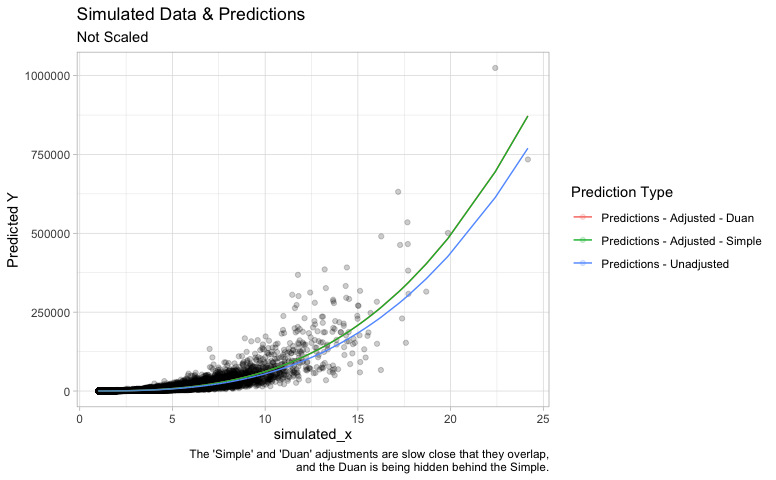

```r
simulated_plot +
    labs(title="Simulated Data & Predictions",
         subtitle = "Not Scaled",
         caption="The 'Simple' and 'Duan' adjustments are slow close that they overlap,\nand the Duan is being hidden behind the Simple.")
```

The adjustments seem to make sense, visualy; but we can check the `Root Mean Square Error` (`RMSE`) to see if the adjustments actually results in a better **out-of-sample** fit, below (which it appears is the case; there is a lower error for the adjusted predictions).

```r
rmse = function(fitted, actual){
  sqrt(mean((fitted - actual)^2))
}

rmse(fitted=test_data$`Predictions - Unadjusted`, actual=test_data$simulated_y)
```

```
## [1] 8968.512
```

```r
rmse(fitted=test_data$`Predictions - Adjusted - Simple`, actual=test_data$simulated_y)
```

```
## [1] 8546.481
```

```r
rmse(fitted=test_data$`Predictions - Adjusted - Duan`, actual=test_data$simulated_y)
```

```
## [1] 8545.582
```

NOTE: the “Simple” adjustment (found in `Introductory Econometrics, Wooldridge (pg. 206)`) is only valid for residuals that are normally distributed. In this simulation, the residuals are normally distributed; and the Simple and Duan adjustments are quite similar.

We can do another performance check using `R-Squared`, which is a measure of the percent of variance in the dependent variable (y) that is explained by the model. The higher the R-squared, the better.

```r
#' these functions are from `Business Data Science, Taddy, pg 72`
#' @param y the actual y values
#' @param pred the predictions; must be probabilities (0<pred<1) for binomial
deviance <- function(y, pred, family=c("gaussian","binomial")){
    family <- match.arg(family)
    if(family=="gaussian"){
        return( sum( (y-pred)^2 ) )
    }else{
        if(is.factor(y)) y <- as.numeric(y)>1
        return( -2*sum( y*log(pred) + (1-y)*log(1-pred) ) )
    }
}
#' these functions are from `Business Data Science, Taddy, pg 72`
#' returns r-squared which is a measure of the percent of variance in the dependent variable (y) that is explained by the model.
#' @param y the actual y values
#' @param pred the predictions; must be probabilities (0<pred<1) for binomial
R2 <- function(y, pred, family=c("gaussian","binomial")){
    fam <- match.arg(family)
    if(fam=="binomial"){
        if(is.factor(y)){ y <- as.numeric(y)>1 }
    }
    dev <- deviance(y, pred, family=fam)
    dev0 <- deviance(y, mean(y), family=fam)
    return(1-dev/dev0)
}
```

We can see that the adjusted predictions do have a higher `R-Squared` than the unadjsuted.

```r
R2(pred=test_data$`Predictions - Unadjusted`, y=test_data$simulated_y)
```

```
## [1] 0.782397
```

```r
R2(pred=test_data$`Predictions - Adjusted - Simple`, y=test_data$simulated_y)
```

```
## [1] 0.8023946
```

```r
R2(pred=test_data$`Predictions - Adjusted - Duan`, y=test_data$simulated_y)
```

```
## [1] 0.8024362
```

# Chapter 4 - Statistcal Inference

## Confidence Interval of Proportion

```r
sample_size <- 1000
respond_yes <- 700

(estimate <- respond_yes / sample_size)
```

```
## [1] 0.7
```

```r
(standard_error <- sqrt(estimate * (1 - estimate) / sample_size))
```

```
## [1] 0.01449138
```

```r
(z_scores <- qnorm(c(0.025, 0.975)))
```

```
## [1] -1.959964  1.959964
```

```r
(confidence_interval_95 <- estimate + (z_scores * standard_error))
```

```
## [1] 0.6715974 0.7284026
```

Compare to R’s `prop.test`.

```r
prop.test(x=respond_yes, n=sample_size)
```

```
##
##  1-sample proportions test with continuity correction
##
## data:  respond_yes out of sample_size, null probability 0.5
## X-squared = 159.2, df = 1, p-value < 0.00000000000000022
## alternative hypothesis: true p is not equal to 0.5
## 95 percent confidence interval:
##  0.6703646 0.7280778
## sample estimates:
##   p
## 0.7
```

# Chapter 5 - Simulation

## How many girls in 400 births?

```r
probability_girl <- 0.488
sample_size <- 400
# one random sample (simulated)
number_of_simulated_samples <- 1
set.seed(1)
rbinom(n = number_of_simulated_samples, size=sample_size, prob = probability_girl)
```

```
## [1] 196
```

```r
number_of_simulated_samples <- 1000
set.seed(1)
simulations <- rbinom(n = number_of_simulated_samples, size=sample_size, prob = probability_girl)
simulations[1:10]
```

```
##  [1] 196 195 184 213 198 183 192 168 178 196
```

95% Interval

```r
quantile(simulations, c(0.025, 0.975))
```

```
##  2.5% 97.5%
##   176   216
```

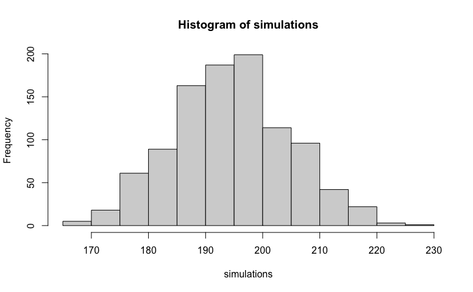

```r
hist(simulations)
```

Accounting for twins.

First, simulate birth types of 400 births.

```r
set.seed(2)
probability_girl_if_twins <- 0.495
probability_of_twins_fraternal <- 1/125  # each has a 49.5% of being a girl
probability_of_twins_identical <- 1/300  # 49.5% chance of being a pair of girls.

simulate_birth_types <- function() {

    sample(x=c('fraternal twin', 'identical twin', 'single born'),
           size = sample_size,
           replace = TRUE,
           prob = c(probability_of_twins_fraternal,
                    probability_of_twins_identical,
                    1 - probability_of_twins_fraternal - probability_of_twins_identical))
}
birth_type <- simulate_birth_types()
table(birth_type)
```

```
## birth_type
## fraternal twin identical twin    single born
##              2              1            397
```

Simulating Number of Girls if Fraternal Twin. In this scenario, there are `2` different people, each of which has a `49.5% percent chance of being a girl. So the possible outcomes are`0`,`1`,`2`

- `0`: 0 girls (both boys)
- `1`: 1 girl
- `2`: 2 both

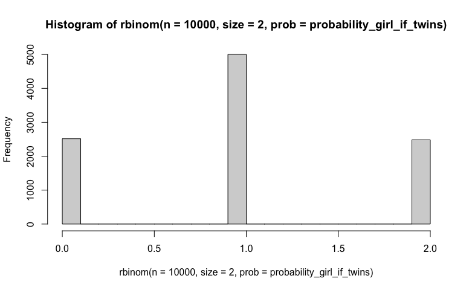

```r
hist(rbinom(n=10000,  # simulate this scenario 10K times
            size=2, # two different possible chances of being a girl
            prob=probability_girl_if_twins))
```

Simulating Number of Girls if Identical Twin. In this scenario, they are either both boys, or both girls. So the possible outcomes are either `0` or `2`

- `0`: 0 girls (both boys)
- `2`: both girls

In other words, we’ll simulate the binary outcome of either both girls or both boys, but the former means we have to count 2 people, so we’ll multiple the number of people by 2

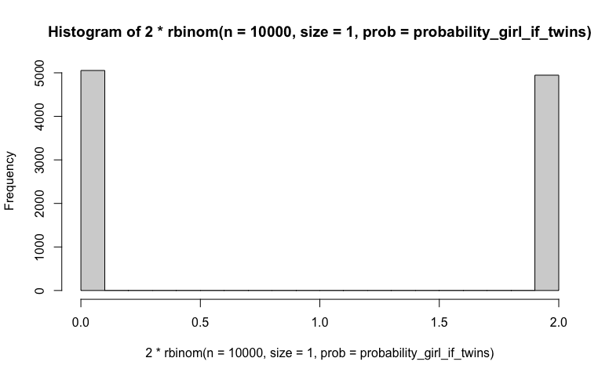

```r
hist(2 * rbinom(n=10000,  # simulate this scenario 10K times
                size=1, # two different possible chances of being a girl
                prob=probability_girl_if_twins))
```

Now, we will do 1000 simulations of births, considering fraternal/identical twins; each simulation has a sample-size of 400.

```r
set.seed(1)
simulation_results <- replicate(1000, {
    birth_type <- simulate_birth_types()

    sample_of_girls <- map_dbl(birth_type, ~ {

        if(. == 'fraternal twin') {
            # simulate number of girls for this particular simulated birth_type
            number_of_girls <- rbinom(n=1,
                   size=2, # two different possible chances of being a girl
                   prob=probability_girl_if_twins)

        } else if(. == 'identical twin') {
            # simulate number of girls for this particular simulated birth_type
            number_of_girls <- 2 * rbinom(n=1,
                size=1, # two different possible chances of being a girl
                prob=probability_girl_if_twins)

        } else if(. == 'single born') {
            # simulate number of girls for this particular simulated birth_type
            number_of_girls <- rbinom(1, 1, probability_girl)

        } else {
            stop()
        }

        return(number_of_girls)
    })
    stopifnot(length(sample_of_girls) == sample_size)
    return (sum(sample_of_girls))
})
```

```r
quantile(simulation_results, c(0.025, 0.975))
```

```
##  2.5% 97.5%
##   178   216
```

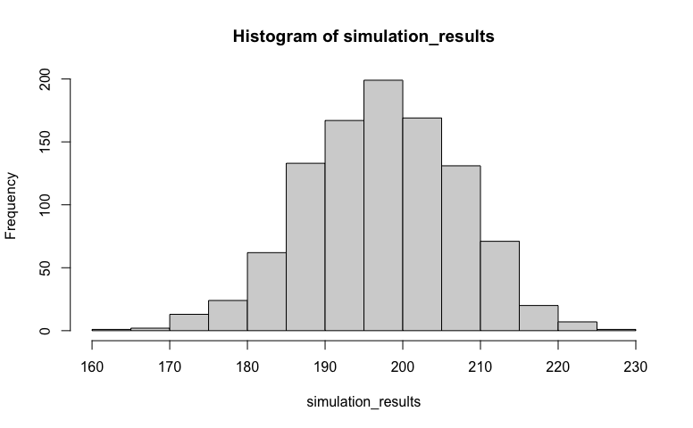

```r
hist(simulation_results)
```

## Simulation of continuous and mixed discrete/continuous models

```r
n_sims <- 1000
y1 <- rnorm(n = n_sims, mean = 3, sd = 0.5)
y2 <- exp(x = y1)
y3 <- rbinom(n = n_sims, size = 20, prob = 0.6)
y4 <- rpois(n = n_sims, lambda = 5)
```

[figure not shown]

## Median Absolute Deviation (`MAD SD`)

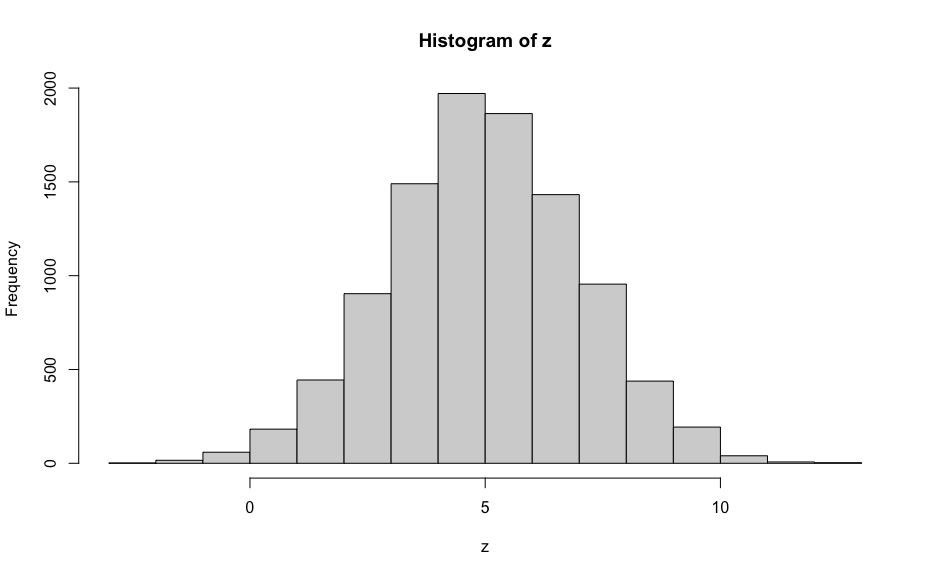

```r
set.seed(1)
z <- rnorm(10000, 5, 2)
hist(z)
```

```r
rnd3 <- function(.x) {
    round(.x, 3)
}
glue::glue("mean = { rnd3(mean(z)) }, sd = { rnd3(sd(z)) }, median = { rnd3(median(z)) }, mad sd = { rnd3(mad(z)) }")
```

```
## mean = 4.987, sd = 2.025, median = 4.968, mad sd = 1.997
```

```r
constant <- 1.4826  # 1.483 defined R&OS pg 73; but function uses more specific number
constant * median(abs(z - median(z)))
```

```
## [1] 1.996752
```

```r
mad(z)
```

```
## [1] 1.996752
```

The above is a single sample if `10,000` observations.

The `standard error` (i.e. expected **standard deviation** of the **distribution** of **sample means** (if we were going to run this simulation many times (or draw a random sample from the population many times))) is:

```r
sd(z) / sqrt(length(z))
```

```
## [1] 0.02024713
```

We can also simulate this.

First, lets run a `1,000` simulations of drawing a sample of `10,000` observations. Each time we’ll take the mean of those 10,000 observations. So we’ll have a distribution of (1000) sample means.

The standard deviation of the distribution of sample means is:

```r
set.seed(1)
simulations <- replicate(1000, mean(rnorm(10000, 5, 2)))
sd(simulations)
```

```
## [1] 0.01941111
```

Which is fairly close to our calculated standard error.

```r
quantile(simulations, c(0.025, 0.975))
```

```
##     2.5%    97.5%
## 4.960204 5.038125
```

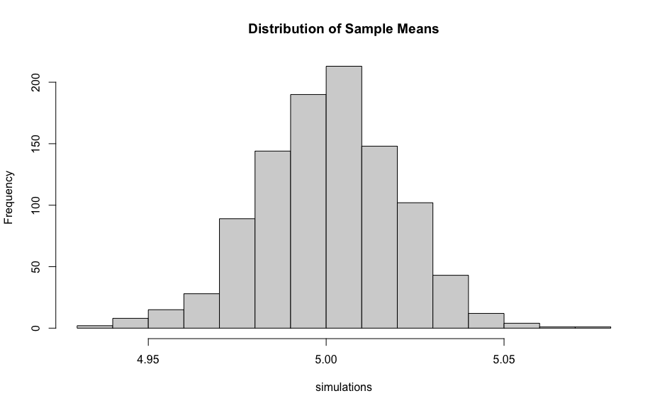

```r
hist(simulations, main = "Distribution of Sample Means")
```

# Chapter 9 - Prediction and Bayesian Inference

```r
head(hibbs)
```

```
##   year growth  vote inc_party_candidate other_candidate
## 1 1952   2.40 44.60           Stevenson      Eisenhower
## 2 1956   2.89 57.76          Eisenhower       Stevenson
## 3 1960   0.85 49.91               Nixon         Kennedy
## 4 1964   4.21 61.34             Johnson       Goldwater
## 5 1968   3.02 49.60            Humphrey           Nixon
## 6 1972   3.62 61.79               Nixon        McGovern
```

```r
# refresh = 0 supresses the default Stan sampling progress output
set.seed(1)
model <- stan_glm(vote ~ growth, data=hibbs, refresh=0)
print(model)
```

```
## stan_glm
##  family:       gaussian [identity]
##  formula:      vote ~ growth
##  observations: 16
##  predictors:   2
## ------
##             Median MAD_SD
## (Intercept) 46.3    1.7
## growth       3.0    0.7
##
## Auxiliary parameter(s):
##       Median MAD_SD
## sigma 3.9    0.7
##
## ------
## * For help interpreting the printed output see ?print.stanreg
## * For info on the priors used see ?prior_summary.stanreg
```

> These numbers are summaries of a matrix of simulations representing different possible values of the parameters (intercept/slope/residual-standard-deviation). `pg. 113`

> We have a set of `posterior simulations` rather than a single point estimate because we have uncertainty about these parameters. `pg. 113`

```r
simulations <- as.matrix(model)
head(simulations)
```

```
##           parameters
## iterations (Intercept)   growth    sigma
##       [1,]    46.84191 2.530584 4.863014
##       [2,]    46.82430 2.902973 3.000165
##       [3,]    45.71522 2.970800 4.020096
##       [4,]    46.84615 3.099256 3.573461
##       [5,]    46.14691 2.877877 3.853315
##       [6,]    42.49051 4.333150 4.803818
```

The above matrix has columns for each model parameter (plus a column for `sigma` which is the `residual standard deviation`). Each row is a simulated outcome.

In the first simulation, the `Intercept` is `46.8419112`, the `growth` coefficient is `2.5305836`, and the `residual standard deviation` is `4.8630139`.

```r
model %>% tidy()
```

```
## # A tibble: 2 x 3
##   term        estimate std.error
##   <chr>          <dbl>     <dbl>
## 1 (Intercept)    46.3      1.74
## 2 growth          3.04     0.741
```

```r
median(simulations[, '(Intercept)'])
```

```
## [1] 46.26798
```

```r
mad(simulations[, '(Intercept)'])
```

```
## [1] 1.74052
```

```r
median(simulations[, 'growth'])
```

```
## [1] 3.040686
```

```r
mad(simulations[, 'growth'])
```

```
## [1] 0.7405457
```

```r
median(simulations[, 'sigma'])
```

```
## [1] 3.900757
```

```r
mad(simulations[, 'sigma'])
```

```
## [1] 0.7097398
```

# pg. 104 describes how sigma (residual standard deviation) is calculated.

They mention that

> a natural way to estimate sigma would be to simply take the standard deviation of the residuals
> $$…$$
> , but this would slightly underestimate sigma because of overfitting…

You can see that if we take the standard deviation of the residuals, we get a slightly lower number than the sigma that is given from the model.

```r
sd(residuals(model))
```

```
## [1] 3.635787
```

Direct calculation:

```r
num_coefficients <- length(coefficients(model))
sqrt(sum(residuals(model)^2) / (length(residuals(model)) - num_coefficients))
```

```
## [1] 3.763442
```

Although this is still lower, I assume because there is some simulation happening rather than the direct calculation.

The residuals are equivalent to `actual - fitted`:

```r
all(model$y - fitted(model) == residuals(model))
```

```
## [1] TRUE
```

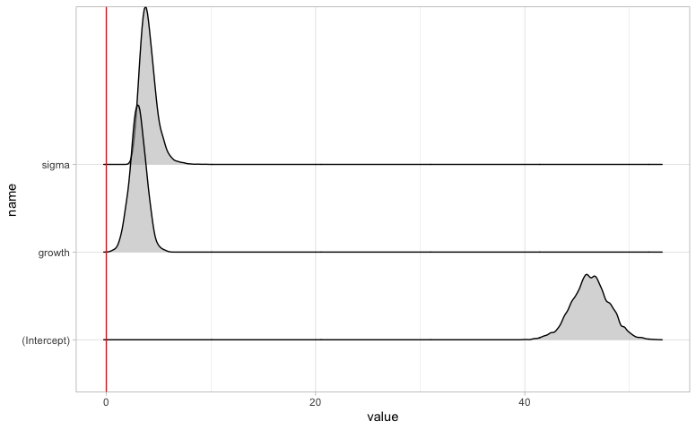

```r
simulations %>%
    as.data.frame() %>%
    mutate(index=row_number()) %>%
    pivot_longer(-index) %>%
    #mutate(stat.sig = factor(stat.sig, levels=c("TRUE", "FALSE"))) %>%
    #mutate(name = fct_reorder(name, coef_median)) %>%
    ggplot(aes(x=value, y=name)) +
    geom_density_ridges(alpha=0.5) +
    geom_vline(xintercept = 0, color='red')
```

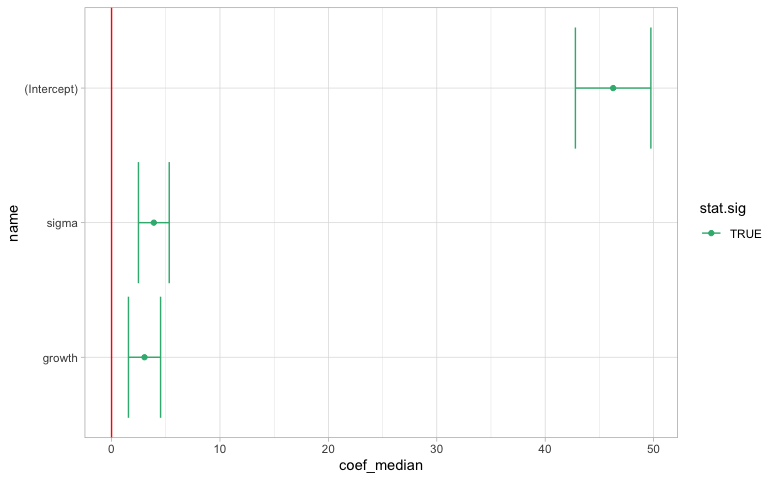

```r
simulations %>%
    as.data.frame() %>%
    mutate(index=row_number()) %>%
    pivot_longer(-index) %>%
    group_by(name) %>%
    summarise(coef_median = median(value),
              coef_mad = mad(value),
              conf.low = coef_median - 2*coef_mad,
              conf.high = coef_median + 2*coef_mad,
              # this is sudo p.value
              # it's the percent of times the simulated values are below zero (if coef_median is greater than zero), or vice-versa
              p.value=ifelse(coef_median > 0, sum(value <= 0) / n(), sum(value >= 0) / n()),
              stat.sig = p.value <= 0.05) %>%
    ungroup() %>%
    mutate(stat.sig = factor(stat.sig, levels=c("TRUE", "FALSE"))) %>%
    mutate(name = fct_reorder(name, coef_median)) %>%
    ggplot(aes(x=coef_median, y=name, color=stat.sig)) +
    geom_point() +
    geom_vline(xintercept = 0, color='red') +
    geom_errorbar(aes(xmin=conf.low, xmax=conf.high)) +
    scale_color_manual(values=c("#37B57F", "#DF585C"))
```

## Point Prediction

```r
new_data <- data.frame(growth=2.0)
predict(object = model, newdata = new_data)
```

```
##        1
## 52.36826
```

## Linear Predictor with Uncertainty

> We can use `posterior_linpred` to get uncertainty in the value of the fitted regression line. (pg. 116)

```r
y_linpredict <- posterior_linpred(object=model, newdata = new_data)
head(y_linpredict)
```

```
##
## iterations        1
##       [1,] 51.90308
##       [2,] 52.63024
##       [3,] 51.65682
##       [4,] 53.04466
##       [5,] 51.90266
##       [6,] 51.15681
```

> Equivalently we can use the function `posterior_epred`, which returns the expected prediction for a new data point. For linear regression, the expected value is the same as the linear predcitor, but as we dicuss in Chapter 13, these two quantities differ for nonlinear models. (pg 116)

```r
head(posterior_epred(object=model, newdata = new_data))
```

```
##
## iterations        1
##       [1,] 51.90308
##       [2,] 52.63024
##       [3,] 51.65682
##       [4,] 53.04466
##       [5,] 51.90266
##       [6,] 51.15681
```

To understand what these predictions are, we could have calculated them by hand using the simulations output.

```r
simulations %>%
    as.data.frame() %>%
    select(-sigma) %>%
    mutate(prediction = `(Intercept)` + growth * 2.0) %>%
    head()
```

```
##   (Intercept)   growth prediction
## 1    46.84191 2.530584   51.90308
## 2    46.82430 2.902973   52.63024
## 3    45.71522 2.970800   51.65682
## 4    46.84615 3.099256   53.04466
## 5    46.14691 2.877877   51.90266
## 6    42.49051 4.333150   51.15681
```

```r
simulate_election_results_linpred_conf_int <- function(.growth) {

    predictions <- posterior_linpred(object=model, newdata = data.frame(growth=.growth))
    confidence_intervals <- quantile(predictions, c(0.025, 0.975))
    data.frame(prediction=median(predictions),
               conf.low=unname(confidence_intervals[1]),
               conf.high=unname(confidence_intervals[2]))
}
simulate_election_results_linpred_conf_int(2)
```

```
##   prediction conf.low conf.high
## 1   52.36062 50.39318  54.40416
```

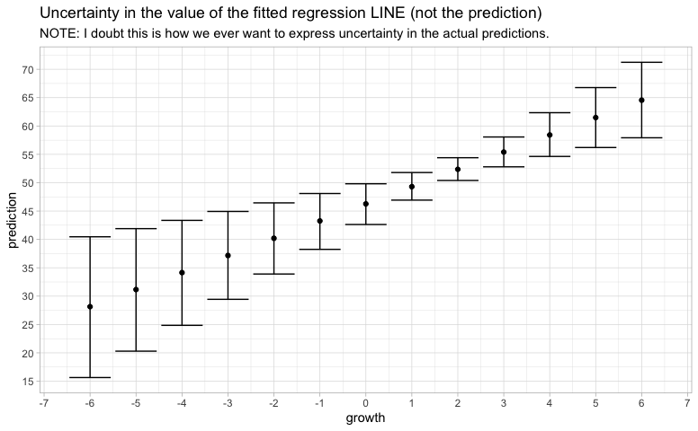

```r
data.frame(growth = -6:6) %>%
    mutate(results = map(growth, ~simulate_election_results_linpred_conf_int(.growth=.))) %>%
    unnest(results) %>%
    ggplot(aes(x=growth, y=prediction)) +
    geom_point() +
    geom_errorbar(aes(ymin=conf.low, ymax=conf.high)) +
    scale_x_continuous(breaks = pretty_breaks(20)) +
    scale_y_continuous(breaks = pretty_breaks(10)) +
    labs(title="Uncertainty in the value of the fitted regression LINE (not the prediction)",
         subtitle="NOTE: I doubt this is how we ever want to express uncertainty in the actual predictions.")
```

NOTE: I doubt this is how we ever want to express uncertainty in the actual predictions.

## Predictive Distribution

> We can construct a vector representing **predictive uncertainty** in a single election.

Note the confidence intervals are being simulated so the numbers/graph will change each time unless a seed is set.

```r
new_data
```

```
##   growth
## 1      2
```

```r
set.seed(1)
y_pred <- posterior_predict(object = model, newdata = new_data)
head(y_pred)
```

```
##             1
## [1,] 48.85662
## [2,] 53.18120
## [3,] 48.29752
## [4,] 58.74534
## [5,] 53.17236
## [6,] 47.21543
```

If we were to do this by hand, we do the same as before, but add the error term to the computation (which assumes normal distribution).

Therefore, in generating the values of `prediction` (i.e. the prediction distribution for the single prediction we are concerned with in this example) `posterior_predict` is taking into account both the uncertainty of the coefficients (because each simulation uses the simulated coefficients) but also the uncertainty in the prediction (because each simulation is simulating the error from the residual standard error, sigma).

```r
set.seed(1)
simulations %>%
    as.data.frame() %>%
    mutate(error = rnorm(nrow(simulations), 0, sigma)) %>%
    mutate(prediction = `(Intercept)` + growth*2.0 + error) %>%  # 2.0 for the growth we are using for our prediction
    head()
```

```
##   (Intercept)   growth    sigma      error prediction
## 1    46.84191 2.530584 4.863014 -3.0464536   48.85662
## 2    46.82430 2.902973 3.000165  0.5509602   53.18120
## 3    45.71522 2.970800 4.020096 -3.3593075   48.29752
## 4    46.84615 3.099256 3.573461  5.7006740   58.74534
## 5    46.14691 2.877877 3.853315  1.2696974   53.17236
## 6    42.49051 4.333150 4.803818 -3.9413812   47.21543
```

```r
simulate_election_results_predict_conf_int <- function(.growth) {

    predictions <- posterior_predict(object=model, newdata = data.frame(growth=.growth))
    confidence_intervals_68 <- quantile(predictions, c(0.16, 1-0.16))
    confidence_intervals_95 <- quantile(predictions, c(0.025, 0.975))
    data.frame(prediction=median(predictions),
               conf.low.68=unname(confidence_intervals_68[1]),
               conf.high.68=unname(confidence_intervals_68[2]),
               conf.low.95=unname(confidence_intervals_95[1]),
               conf.high.95=unname(confidence_intervals_95[2]),
               probability_50_plus = mean(predictions > 50)) %>%
        mutate(stat.sig = !between(50, conf.low.95, conf.high.95))
}
set.seed(1)
simulate_election_results_predict_conf_int(2)
```

```
##   prediction conf.low.68 conf.high.68 conf.low.95 conf.high.95
## 1   52.34582     48.1972     56.60639    43.25028     61.14292
##   probability_50_plus stat.sig
## 1               0.719    FALSE
```

```r
set.seed(1)
results <- data.frame(growth = -6:6) %>%
    mutate(results = map(growth, ~simulate_election_results_predict_conf_int(.growth=.))) %>%
    unnest(results)
results
```

```
## # A tibble: 13 x 8
##    growth prediction conf.low.68 conf.high.68 conf.low.95 conf.high.95
##     <int>      <dbl>       <dbl>        <dbl>       <dbl>        <dbl>
##  1     -6       28.1        20.6         35.2        12.9         43.2
##  2     -5       31.0        24.3         37.6        17.5         44.5
##  3     -4       34.1        28.2         40.1        21.7         46.6
##  4     -3       37.0        31.8         42.5        26.1         48.7
##  5     -2       40.3        35.3         45.2        30.1         50.6
##  6     -1       43.4        38.8         47.9        34.1         52.8
##  7      0       46.3        42.0         50.6        37.5         55.2
##  8      1       49.3        45.2         53.6        40.7         58.1
##  9      2       52.3        48.2         56.4        44.2         60.7
## 10      3       55.4        51.1         59.3        46.7         63.7
## 11      4       58.5        54.1         62.8        49.6         67.7
## 12      5       61.5        56.6         66.2        51.6         71.1
## 13      6       64.4        59.4         69.7        54.3         75.4
## # … with 2 more variables: probability_50_plus <dbl>, stat.sig <lgl>
```

Note the confidence intervals are being simulated so the numbers/graph will change each time unless a seed is set.

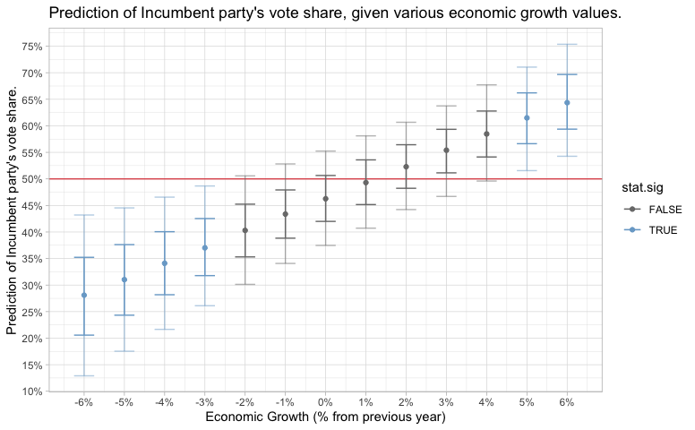

```r
results %>%
    ggplot(aes(x=growth, y=prediction, color=stat.sig)) +
    geom_hline(yintercept = 50, color="#DF585C") +
    geom_point() +
    geom_errorbar(aes(ymin=conf.low.68, ymax=conf.high.68), width=0.5) +
    geom_errorbar(aes(ymin=conf.low.95, ymax=conf.high.95), width=0.5, alpha=0.5) +
    scale_x_continuous(breaks = pretty_breaks(10), labels = function(.x)paste0(.x, "%")) +
    scale_y_continuous(breaks = pretty_breaks(10), labels = function(.x)paste0(.x, "%")) +
    scale_color_manual(values=c("#7A7A7A", "#7AA9CF")) +
    labs(title="Prediction of Incumbent party's vote share, given various economic growth values.",
         x="Economic Growth (% from previous year)",
         y="Prediction of Incumbent party's vote share.")
```

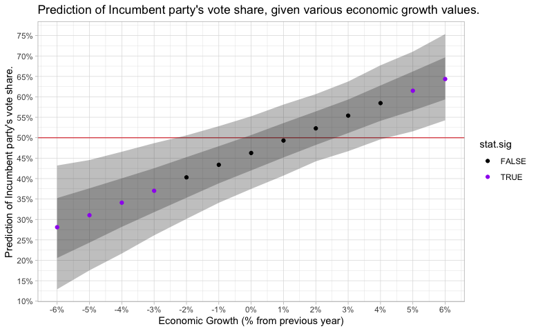

```r
results %>%
    ggplot(aes(x=growth, y=prediction)) +
    geom_hline(yintercept = 50, color="#DF585C") +
    geom_ribbon(aes(ymin=conf.low.68, ymax=conf.high.68), alpha=0.3) +
    geom_ribbon(aes(ymin=conf.low.95, ymax=conf.high.95), alpha=0.3) +
    geom_point(aes(color=stat.sig)) +
    #geom_point() +
    #geom_errorbar(aes(ymin=conf.low, ymax=conf.high), width=0.5) +
    scale_x_continuous(breaks = pretty_breaks(10), labels = function(.x)paste0(.x, "%")) +
    scale_y_continuous(breaks = pretty_breaks(10), labels = function(.x)paste0(.x, "%")) +
    scale_color_manual(values=c("black", "purple")) +
    labs(title="Prediction of Incumbent party's vote share, given various economic growth values.",
         x="Economic Growth (% from previous year)",
         y="Prediction of Incumbent party's vote share.")
```

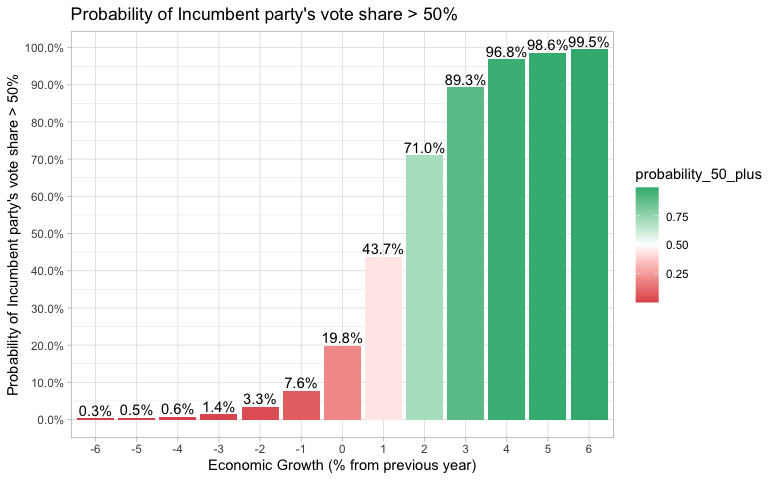

```r
results %>%
    mutate(growth = factor(growth)) %>%
    ggplot(aes(x=growth, y=probability_50_plus, fill=probability_50_plus)) +
    geom_col() +
    geom_text(aes(label=percent(probability_50_plus, accuracy = 0.1)), vjust=-0.3) +
    scale_y_continuous(breaks=pretty_breaks(10), labels = scales::percent_format()) +
    #scale_fill_gradient2(low = 'red', mid = 'white', high = 'green', midpoint = 0.5) +
    scale_fill_gradient2(low = '#DF585C', mid = 'white', high = '#37B57F', midpoint = 0.5) +
    labs(title="Probability of Incumbent party's vote share > 50%",
         x="Economic Growth (% from previous year)",
         y="Probability of Incumbent party's vote share > 50%")
```

If we were to predict on several instances, we would get a column for each input value (i.e. growth of `-2` corresponds to column `1`)

```r
head(posterior_predict(object=model, newdata = data.frame(growth=-2:2)))
```

```
##             1        2        3        4        5
## [1,] 45.27913 52.20514 52.97842 51.54050 52.31903
## [2,] 37.87475 45.27452 46.82971 52.26231 51.79659
## [3,] 37.82885 38.58577 50.82949 52.24572 53.61926
## [4,] 41.21643 43.19611 52.94486 53.67422 59.15144
## [5,] 32.36262 43.02670 44.72471 51.53579 52.36188
## [6,] 33.89755 36.03021 44.76809 50.10132 50.34956
```

```r
all_predictions <- posterior_predict(object=model, newdata = data.frame(growth=-6:6))
head(all_predictions, 20)
```

```
##              1        2        3        4        5        6        7        8
##  [1,] 29.29867 33.47077 31.20519 34.86864 36.32780 46.79522 46.24110 49.91782
##  [2,] 33.35378 32.32523 33.05214 30.53339 36.78469 46.62747 49.38844 48.62294
##  [3,] 28.35478 26.75146 36.20021 44.03903 41.32497 51.64486 51.90316 46.57130
##  [4,] 29.53539 38.18211 32.47686 42.60024 35.80299 42.03948 45.15819 50.57974
##  [5,] 31.99193 28.82617 41.54866 33.69848 38.94106 42.71838 45.02369 49.32241
##  [6,] 16.56992 18.97997 29.09234 21.44021 32.88386 40.07409 38.05889 47.07490
##  [7,] 20.05567 28.53333 22.43962 36.83751 29.79699 43.62252 42.79077 54.59286
##  [8,] 22.81106 29.69341 29.24047 36.44407 36.12902 39.25654 48.72938 56.22365
##  [9,] 33.96514 35.81379 42.10013 40.08134 56.41840 37.32529 52.91800 46.10469
## [10,] 32.24065 32.62485 43.88731 39.26625 41.26822 42.81838 45.25648 59.35609
## [11,] 27.26866 29.51533 37.21186 40.65057 42.18993 46.95509 48.26741 49.78173
## [12,] 29.70068 21.83215 33.18967 32.82051 46.36280 44.94180 51.52523 53.55504
## [13,] 32.79545 34.23412 31.63193 42.09595 37.35913 43.42236 47.20777 52.67891
## [14,] 37.10348 37.94721 34.02531 45.30308 45.85839 43.89719 50.89641 51.26916
```

[output cut: 27 more lines]

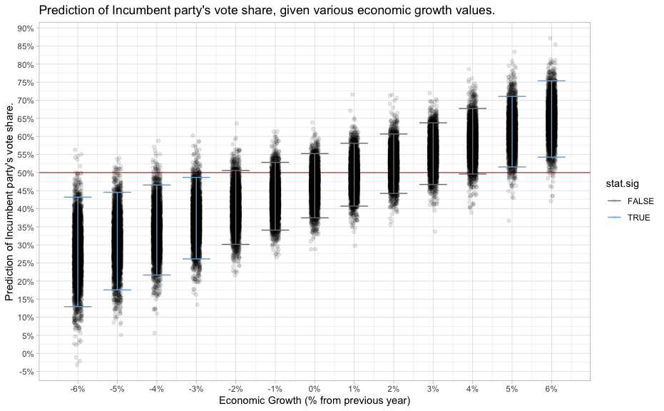

```r
all_predictions <- all_predictions %>%
    as.data.frame() %>%
    mutate(temp=1) %>%
    pivot_longer(-temp, names_to='growth', values_to='prediction') %>%
    mutate(growth = as.numeric(growth) - 6 - 1) %>%
    select(-temp)

results %>%
    ggplot(aes(x=growth, y=prediction, color=stat.sig)) +
    geom_hline(yintercept = 50, color="#DF585C") +
    #geom_point() +
    geom_jitter(data=all_predictions, aes(x=growth, y=prediction, color=NULL), width=0.1, alpha=0.1) +
    #geom_errorbar(aes(ymin=conf.low.68, ymax=conf.high.68), width=0.5) +
    geom_errorbar(aes(ymin=conf.low.95, ymax=conf.high.95), width=0.7) +
    scale_x_continuous(breaks = pretty_breaks(10), labels = function(.x)paste0(.x, "%")) +
    scale_y_continuous(breaks = pretty_breaks(20), labels = function(.x)paste0(.x, "%")) +
    scale_color_manual(values=c("#7A7A7A", "#7AA9CF")) +
    labs(title="Prediction of Incumbent party's vote share, given various economic growth values.",
         x="Economic Growth (% from previous year)",
         y="Prediction of Incumbent party's vote share.")
```

## 9.3 Prior Information and Bayesian Synthesis

Prior estimate and standard deviation

```r
bayesian_updating <- function(.new_vote_count, .new_sample_size) {

    prior_estimate <- 0.524
    prior_estimate_sd <- 0.041

    (data_estimate <- .new_vote_count / .new_sample_size)
    (data_estimate_sd <- sqrt((.new_vote_count / .new_sample_size) * (1 - (.new_vote_count / .new_sample_size)) / .new_sample_size))

    (bayes_estimate <- ((prior_estimate / (prior_estimate_sd^2)) + (data_estimate / (data_estimate_sd^2))) / ((1 / (prior_estimate_sd^2)) + (1 / (data_estimate_sd^2))))
    (bayes_estimate_sd <- 1 / sqrt((1 / (prior_estimate_sd^2)) + (1 / (data_estimate_sd^2))))

    print(glue::glue("Prior: { prior_estimate }; Likelihood: { data_estimate }; Posterior: { round(bayes_estimate, 4) }; standard deviation: { round(bayes_estimate_sd, 4) }"))

    x <- seq(0, 1, length.out = 1000)
    data.frame(type="Prior Distribution", x=x, value=dnorm(x, prior_estimate, prior_estimate_sd)) %>%
        bind_rows(data.frame(type="Likelihood / Data Distribution", x=x, value=dnorm(x, data_estimate, data_estimate_sd))) %>%
        bind_rows(data.frame(type="Posterior", x=x, value=dnorm(x, bayes_estimate, bayes_estimate_sd))) %>%
        mutate(type = factor(type, levels=c('Prior Distribution', 'Likelihood / Data Distribution', 'Posterior'))) %>%
        ggplot(aes(x=x, y=value, color=type)) +
        geom_line() +
        coord_cartesian(xlim=c(0.4, 0.65)) +
        scale_x_continuous(breaks = pretty_breaks(10), labels = scales::percent_format(accuracy = 1)) +
        theme(axis.title.y=element_blank(),
              axis.text.y=element_blank(),
              axis.ticks.y=element_blank()) +
        labs(title='Bayesian Updating',
             x='% Voting Democrat')
}
```

```r
bayesian_updating(.new_vote_count = 19, .new_sample_size = 40)
```

```
## Prior: 0.524; Likelihood: 0.475; Posterior: 0.5136; standard deviation: 0.0364
```

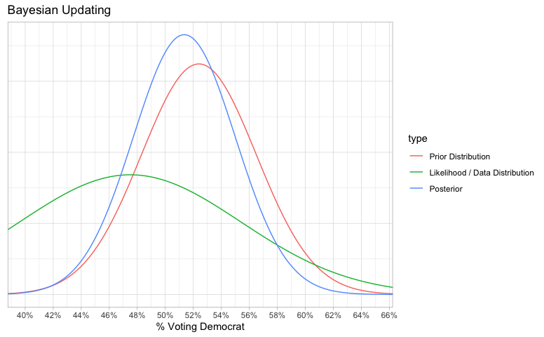

```r
bayesian_updating(.new_vote_count = 95, .new_sample_size = 200)
```

```
## Prior: 0.524; Likelihood: 0.475; Posterior: 0.4959; standard deviation: 0.0268
```

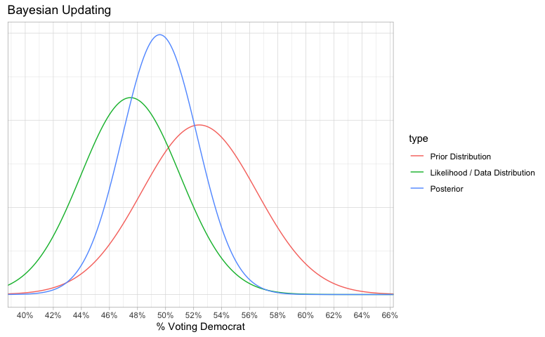

```r
bayesian_updating(.new_vote_count = 190, .new_sample_size = 400)
```

```
## Prior: 0.524; Likelihood: 0.475; Posterior: 0.4883; standard deviation: 0.0213
```

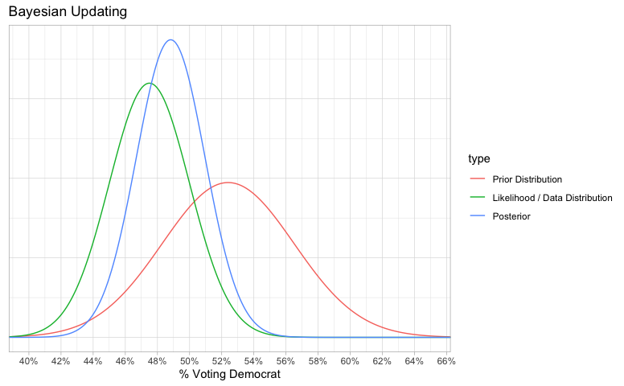

## 9.5 Uniform, weakly informative, and informative priors in regression

### Uniform prior distribution

> We can run `stan_glm` with uniform prior densities for the scale parameter using the `NULL` option. (pg. 123)

```r
uniform_model <- stan_glm(vote ~ growth, data=hibbs,
                          refresh = 0,  # refresh = 0 supresses the default Stan sampling progress output
                          prior_intercept = NULL,
                          prior = NULL,
                          prior_aux = NULL)
print(uniform_model)
```

```
## stan_glm
##  family:       gaussian [identity]
##  formula:      vote ~ growth
##  observations: 16
##  predictors:   2
## ------
##             Median MAD_SD
## (Intercept) 46.2    1.7
## growth       3.1    0.8
##
## Auxiliary parameter(s):
##       Median MAD_SD
## sigma 4.0    0.8
##
## ------
## * For help interpreting the printed output see ?print.stanreg
## * For info on the priors used see ?prior_summary.stanreg
```

Compare to `lm`; close but not the same.

```r
lm_model <- lm(vote ~ growth, data=hibbs)

coef(lm_model)
```

```
## (Intercept)      growth
##   46.247648    3.060528
```

```r
coef(uniform_model)
```

```
## (Intercept)      growth
##    46.22482     3.06300
```

> These numbers are summaries of a matrix of simulations representing different possible values of the parameters (intercept/slope/residual-standard-deviation). `pg. 113`

> We have a set of `posterior simulations` rather than a single point estimate because we have uncertainty about these parameters. `pg. 113`

```r
uniform_coef_simulations <- as.matrix(uniform_model)
head(uniform_coef_simulations)
```

```
##           parameters
## iterations (Intercept)   growth    sigma
##       [1,]    44.27704 4.176405 4.495793
##       [2,]    48.51854 1.642577 3.804167
##       [3,]    48.53083 1.400092 4.137344
##       [4,]    44.28250 4.442634 3.482860
##       [5,]    45.09045 3.466920 4.832289
##       [6,]    45.45151 4.391790 3.407798
```

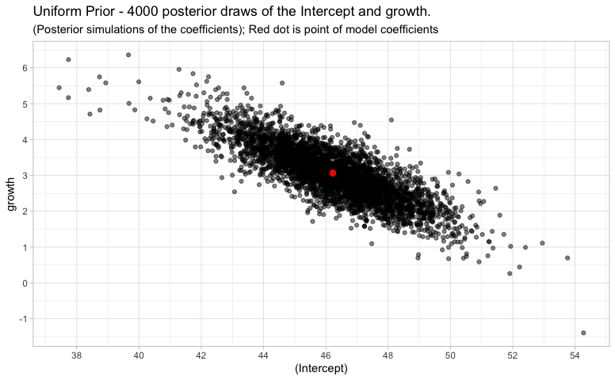

```r
uniform_coef_simulations %>%
    as.data.frame() %>%
    ggplot(aes(x=`(Intercept)`, y=growth)) +
    geom_point(alpha = 0.5) +
    geom_point(x=coef(uniform_model)['(Intercept)'], y=coef(uniform_model)['growth'], size=2, color='red') +
    scale_x_continuous(breaks = pretty_breaks(10)) +
    scale_y_continuous(breaks = pretty_breaks(10)) +
    labs(title = "Uniform Prior - 4000 posterior draws of the Intercept and growth.",
         subtitle = "(Posterior simulations of the coefficients); Red dot is point of model coefficients")
```

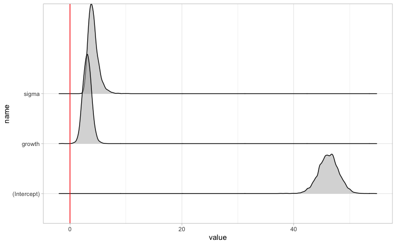

```r
uniform_coef_simulations %>%
    as.data.frame() %>%
    mutate(index=row_number()) %>%
    pivot_longer(-index) %>%
    #mutate(stat.sig = factor(stat.sig, levels=c("TRUE", "FALSE"))) %>%
    #mutate(name = fct_reorder(name, coef_median)) %>%
    ggplot(aes(x=value, y=name)) +
    geom_density_ridges(alpha=0.5) +
    geom_vline(xintercept = 0, color='red')
```

```r
# Note that if we don't set.seed the predictions will change because they are being simulated
simulate_election_results_predict_conf_int <- function(.model, .growth) {

    predictions <- posterior_predict(object=.model, newdata = data.frame(growth=.growth))
    confidence_intervals_68 <- quantile(predictions, c(0.16, 1-0.16))
    confidence_intervals_95 <- quantile(predictions, c(0.025, 0.975))
    data.frame(prediction=median(predictions),
               conf.low.68=unname(confidence_intervals_68[1]),
               conf.high.68=unname(confidence_intervals_68[2]),
               conf.low.95=unname(confidence_intervals_95[1]),
               conf.high.95=unname(confidence_intervals_95[2]),
               probability_50_plus = mean(predictions > 50)) %>%
        mutate(stat.sig = !between(50, conf.low.95, conf.high.95))
}
set.seed(1)
simulate_election_results_predict_conf_int(.model=uniform_model, .growth=2)
```

```
##   prediction conf.low.68 conf.high.68 conf.low.95 conf.high.95
## 1   52.27329    48.08116     56.68598    43.52937     61.56743
##   probability_50_plus stat.sig
## 1             0.71725    FALSE
```

```r
set.seed(1)
uniform_prediction_summary <- data.frame(growth = -6:6) %>%
    mutate(results = map(growth, ~simulate_election_results_predict_conf_int(.model=uniform_model, .growth=.))) %>%
    unnest(results)
head(uniform_prediction_summary)
```

```
## # A tibble: 6 x 8
##   growth prediction conf.low.68 conf.high.68 conf.low.95 conf.high.95
##    <int>      <dbl>       <dbl>        <dbl>       <dbl>        <dbl>
## 1     -6       27.9        20.5         35.0        12.2         42.6
## 2     -5       30.8        24.3         37.4        16.9         43.9
## 3     -4       33.9        27.7         40.0        21.4         45.7
## 4     -3       37.1        31.5         42.4        25.4         48.6
## 5     -2       40.1        35.2         45.2        29.9         50.2
## 6     -1       43.4        38.6         47.9        33.4         52.6
## # … with 2 more variables: probability_50_plus <dbl>, stat.sig <lgl>
```

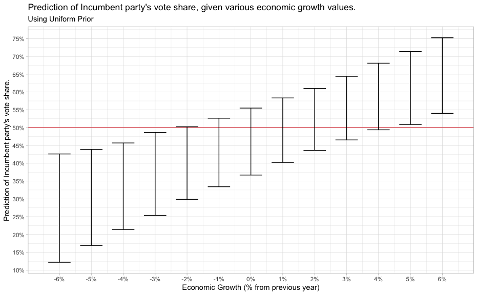

```r
uniform_prediction_summary %>%
    ggplot(aes(x=growth, y=prediction)) +
    geom_hline(yintercept = 50, color="#DF585C") +
    #geom_point() +
    #geom_jitter(data=all_predictions, aes(x=growth, y=prediction, color=NULL), width=0.1, alpha=0.1) +
    #geom_errorbar(aes(ymin=conf.low.68, ymax=conf.high.68), width=0.5) +
    geom_errorbar(aes(ymin=conf.low.95, ymax=conf.high.95), width=0.7) +
    scale_x_continuous(breaks = pretty_breaks(10), labels = function(.x)paste0(.x, "%")) +
    scale_y_continuous(breaks = pretty_breaks(20), labels = function(.x)paste0(.x, "%")) +
    scale_color_manual(values=c("#7A7A7A", "#7AA9CF")) +
    labs(title="Prediction of Incumbent party's vote share, given various economic growth values.",
         subtitle="Using Uniform Prior",
         x="Economic Growth (% from previous year)",
         y="Prediction of Incumbent party's vote share.")
```

### Default Prior Distribution

> The default prior distribution can be specified implicitly (using the defaults): (pg. 124)

```r
set.seed(1)
default_prior_model <- stan_glm(vote ~ growth, data=hibbs, refresh=0)
print(default_prior_model)
```

```
## stan_glm
##  family:       gaussian [identity]
##  formula:      vote ~ growth
##  observations: 16
##  predictors:   2
## ------
##             Median MAD_SD
## (Intercept) 46.3    1.7
## growth       3.0    0.7
##
## Auxiliary parameter(s):
##       Median MAD_SD
## sigma 3.9    0.7
##
## ------
## * For help interpreting the printed output see ?print.stanreg
## * For info on the priors used see ?prior_summary.stanreg
```

> or explicitly, below. The particular choice of `2.5` as a scaling factor is somewhat arbitrary, chosen to provide some stability in estimation while have little influence on the coefficient estimate when data are even moderately informative.

```r
sd_x <- sd(hibbs$growth)
sd_y <- sd(hibbs$vote)
mean_y <- mean(hibbs$vote)


growth_prior_mean <- 0
growth_prior_sd <- 2.5 * sd_y / sd_x

set.seed(1)
default_prior_explicit_model <- stan_glm(vote ~ growth, data=hibbs,
                                         refresh = 0,  # refresh = 0 supresses the default Stan sampling progress output
                                         prior = rstanarm::normal(location = growth_prior_mean, scale = growth_prior_sd),
                                         prior_intercept = rstanarm::normal(location = mean_y, scale = 2.5 * sd_y),
                                         prior_aux = rstanarm::exponential(1 / sd_y))
print(default_prior_explicit_model)
```

```
## stan_glm
##  family:       gaussian [identity]
##  formula:      vote ~ growth
##  observations: 16
##  predictors:   2
## ------
##             Median MAD_SD
## (Intercept) 46.3    1.7
## growth       3.0    0.7
##
## Auxiliary parameter(s):
##       Median MAD_SD
## sigma 3.9    0.7
##
## ------
## * For help interpreting the printed output see ?print.stanreg
## * For info on the priors used see ?prior_summary.stanreg
```

> These two models are the same (need to set.seed) with the only difference being that for the latter we specified the priors directly.

```r
coef(default_prior_model)
```

```
## (Intercept)      growth
##   46.267981    3.040686
```

```r
coef(default_prior_explicit_model)
```

```
## (Intercept)      growth
##   46.267981    3.040686
```

Not much difference in this case between the `uniform` and the `default`:

```r
coef(default_prior_model)
```

```
## (Intercept)      growth
##   46.267981    3.040686
```

```r
coef(uniform_model)
```

```
## (Intercept)      growth
##    46.22482     3.06300
```

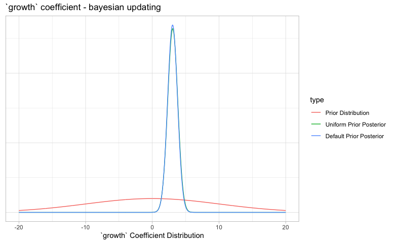

```r
growth_estimate_default_prior <- default_prior_model %>%
    tidy() %>%
    filter(term == 'growth')

growth_estimate_uniform_prior <- uniform_model %>%
    tidy() %>%
    filter(term == 'growth')

x <- seq(-20, 20, length.out = 1000)
data.frame(type="Prior Distribution", x=x, value=dnorm(x, growth_prior_mean, growth_prior_sd)) %>%
    bind_rows(data.frame(type="Uniform Prior Posterior", x=x, value=dnorm(x, growth_estimate_uniform_prior$estimate, growth_estimate_uniform_prior$std.error))) %>%
    bind_rows(data.frame(type="Default Prior Posterior", x=x, value=dnorm(x, growth_estimate_default_prior$estimate, growth_estimate_default_prior$std.error))) %>%
    mutate(type = factor(type, levels=c('Prior Distribution', 'Uniform Prior Posterior', 'Default Prior Posterior'))) %>%
    ggplot(aes(x=x, y=value, color=type)) +
    geom_line() +
    #coord_cartesian(xlim=c(0.4, 0.65)) +
    #scale_x_continuous(breaks = pretty_breaks(10), labels = scales::percent_format(accuracy = 1)) +
    theme(axis.title.y=element_blank(),
          axis.text.y=element_blank(),
          axis.ticks.y=element_blank()) +
    labs(title='`growth` coefficient - bayesian updating',
         x='`growth` Coefficient Distribution')
```

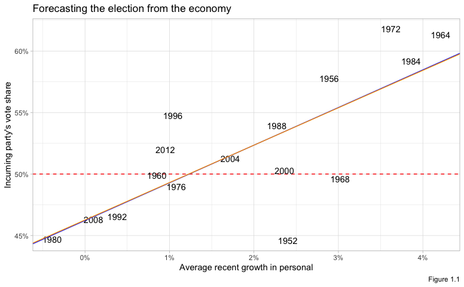

```r
hibbs %>%
    ggplot(aes(x=growth, y=vote)) +
    geom_hline(yintercept = 50, color="red", linetype="dashed") +
    geom_text(aes(label=year)) +
    #geom_smooth(method='lm') +
    geom_abline(intercept = coef(uniform_model)['(Intercept)'], slope = coef(uniform_model)['growth'], color='blue') +
    geom_abline(intercept = coef(default_prior_model)['(Intercept)'], slope = coef(default_prior_model)['growth'], color='orange') +
    scale_x_continuous(labels=function(.x)paste0(.x, '%')) +
    scale_y_continuous(labels=function(.x)paste0(.x, '%')) +
    labs(title="Forecasting the election from the economy",
         y="Incuming party's vote share",
         x="Average recent growth in personal",
         caption='Figure 1.1')
```

### Weekly informative prior distribution based on subject-matter knowledge

# Chapter 10

## Example: uncertainty in predicting congressional elections

Example from pg 140

```r
head(congress)
```

```
## # A tibble: 6 x 9
##   inc86 inc88 inc90   v86   v88   v90 v86_adj v88_adj v90_adj
##   <dbl> <dbl> <dbl> <dbl> <dbl> <dbl>   <dbl>   <dbl>   <dbl>
## 1     1     1     1 0.745 0.772 0.714   0.745   0.772   0.714
## 2     1     1     1 0.674 0.636 0.597   0.674   0.636   0.597
## 3     1     1     0 0.696 0.665 0.521   0.696   0.665   0.521
## 4    -1    -1    -1 0.465 0.274 0.234   0.465   0.274   0.234
## 5    -1    -1     0 0.391 0.264 0.477   0.391   0.264   0.477
## 6    -1    -1    -1 0.358 0.334 0.256   0.358   0.334   0.256
```

`dem_vote_share` is the democratic share of the two-party vote in each district.

Each row is a single district.

Note that the uncontested elections (i.e. only 1 person running) have original vote shares of `0` or `1` (i.e. dems got 0% or 100% of the vote in the single-person race), and those values were changed to `0.25` and `0.75`. These are the approximate proportion of votes received by the Democratic candidate had the election actually been contested. You will see a cross of values at the `0.25` and `0.75` (more visible on the latter) on the x & y axis.

```r
create_election_results <- function(.current_dem_vote_share,
                                    .prev_dem_vote_share,
                                    .incumbency) {

    election_results <- data.frame(dem_vote_share=.current_dem_vote_share,
                                   prev_dem_vote_share=.prev_dem_vote_share,
                                   incumbency=.incumbency) %>%
        mutate(incumbency = case_when(
                    incumbency == -1 ~ "Rep running reelection",
                    incumbency == 0 ~ "Open", # neither of the two candidates was occupying the seat at the time.
                    incumbency == 1 ~ "Dem running reelection",
                    TRUE ~ 'error'),
               incumbency = factor(incumbency, levels=c("Dem running reelection", "Rep running reelection", "Open")))

    return (election_results)
}
election_results_88 <- create_election_results(congress$v88_adj, congress$v86_adj, congress$inc88)
head(election_results_88)
```

```
##   dem_vote_share prev_dem_vote_share             incumbency
## 1      0.7724427           0.7450362 Dem running reelection
## 2      0.6361816           0.6738455 Dem running reelection
## 3      0.6649283           0.6964566 Dem running reelection
## 4      0.2738342           0.4645901 Rep running reelection
## 5      0.2636131           0.3910945 Rep running reelection
## 6      0.3341927           0.3582454 Rep running reelection
```

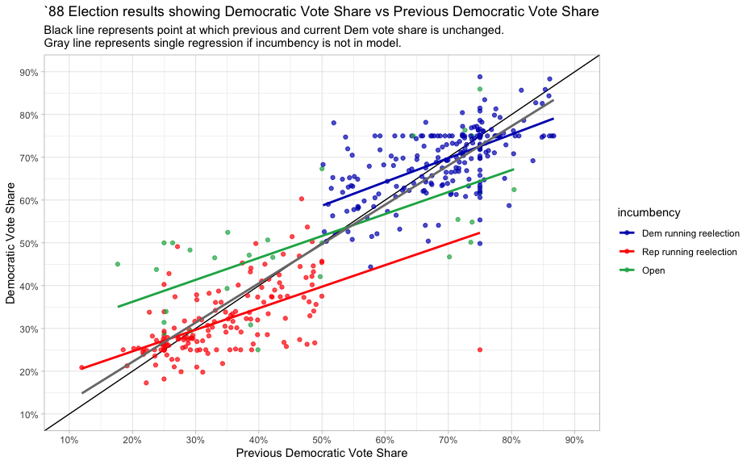

```r
election_results_88 %>%
    ggplot(aes(x=prev_dem_vote_share, y=dem_vote_share, color=incumbency)) +
    geom_abline(intercept = 0, slope = 1) +
    geom_point(alpha=0.7) +
    geom_smooth(method='lm', se=FALSE) +
    geom_smooth(aes(color=NULL), method='lm', se=FALSE, color='#7A7A7A') +
    scale_x_continuous(breaks=pretty_breaks(10), labels=scales::percent_format(1)) +
    scale_y_continuous(breaks=pretty_breaks(10), labels=scales::percent_format(1)) +
    scale_color_manual(values=c("#0015BC", "#FF0000", "#1AAF54")) +
    coord_cartesian(xlim=c(0.1, 0.9), ylim=c(0.1, 0.9)) +
    labs(title="`88 Election results showing Democratic Vote Share vs Previous Democratic Vote Share",
         subtitle = 'Black line represents point at which previous and current Dem vote share is unchanged.\nGray line represents single regression if incumbency is not in model.',
         y="Democratic Vote Share",
         x="Previous Democratic Vote Share")
```

NOTE: In the graph above, the slopes of the colored regression lines are allowed to change with each incumbency group, but the slopes are very close; which suggests there there isn’t much interaction effects; i.e. a model including interaction affects would be very close to a model not including interaction effects.

```r
set.seed(1)
model_88_interactions <- stan_glm(dem_vote_share ~ prev_dem_vote_share*incumbency, data=election_results_88, refresh=0)
print(model_88_interactions, digits=2)
```

```
## stan_glm
##  family:       gaussian [identity]
##  formula:      dem_vote_share ~ prev_dem_vote_share * incumbency
##  observations: 435
##  predictors:   6
## ------
##                                                      Median MAD_SD
## (Intercept)                                           0.31   0.04
## prev_dem_vote_share                                   0.55   0.05
## incumbencyRep running reelection                     -0.16   0.04
## incumbencyOpen                                       -0.05   0.05
## prev_dem_vote_share:incumbencyRep running reelection -0.05   0.08
## prev_dem_vote_share:incumbencyOpen                   -0.04   0.08
##
## Auxiliary parameter(s):
##       Median MAD_SD
## sigma 0.07   0.00
##
## ------
## * For help interpreting the printed output see ?print.stanreg
## * For info on the priors used see ?prior_summary.stanreg
```

NOte: the interaction coefficients are all close to 0 and have a large mad_sd.

```r
set.seed(1)
model_88 <- stan_glm(dem_vote_share ~ prev_dem_vote_share + incumbency, data=election_results_88, refresh=0)
print(model_88, digits=2)
```

```
## stan_glm
##  family:       gaussian [identity]
##  formula:      dem_vote_share ~ prev_dem_vote_share + incumbency
##  observations: 435
##  predictors:   4
## ------
##                                  Median MAD_SD
## (Intercept)                       0.33   0.02
## prev_dem_vote_share               0.53   0.03
## incumbencyRep running reelection -0.19   0.01
## incumbencyOpen                   -0.08   0.01
##
## Auxiliary parameter(s):
##       Median MAD_SD
## sigma 0.07   0.00
##
## ------
## * For help interpreting the printed output see ?print.stanreg
## * For info on the priors used see ?prior_summary.stanreg
```

```r
prediction_data_90 <- create_election_results(.current_dem_vote_share = NA,
                                               .prev_dem_vote_share = election_results_88$dem_vote_share,  # same as congress$v88_adj
                                               .incumbency = congress$inc90) %>%
    select(-dem_vote_share)
head(prediction_data_90)
```

```
##   prev_dem_vote_share             incumbency
## 1           0.7724427 Dem running reelection
## 2           0.6361816 Dem running reelection
## 3           0.6649283                   Open
## 4           0.2738342 Rep running reelection
## 5           0.2636131                   Open
## 6           0.3341927 Rep running reelection
```

```r
set.seed(1)
predictions_90 <- posterior_predict(model_88, newdata=prediction_data_90)
dim(predictions_90)
```

```
## [1] 4000  435
```

Predictions has `4000` simulations (rows) for each of the 435 predicted values, which corresponds to the 435 congressional districts where we are predicting the democratic party’s vote share.